# HAT Monitor Data Visualization Interim Report #1

2025/12/15 Wendy Anthony ER390

## Questions to Ask About HAT Data

- What monitoring management decisions would be made from crew hours, area and species of biomass removed, difference between sites and years
- 2025 Crew data only goes as far as Sept thus not truly comparable, can the rest of the year’s data be made available
- HAT Restoration Crew Data includes multiple invasive species pulled in one date without apportioning amounts … what invasive species make up the most biomass and does this change over time at same site?
- Matson Mattocks Field Log: is this available in a spreadsheet - could show a more complete picture of how much invasive species is being removed by HAT crew and volunteers

## Timelines and Future Directions

- My ER390 course deadlines include submitting my Final Report Paper by 2026-04-15, and arranging to make a final present to HAT by 2026-05-08
- I continue to work on making an interactive, user-choice interface to choose which sites, years and variables to visualize
- I would like to meet with HAT in the very early weeks of January for feedback, direction and clarification of some data

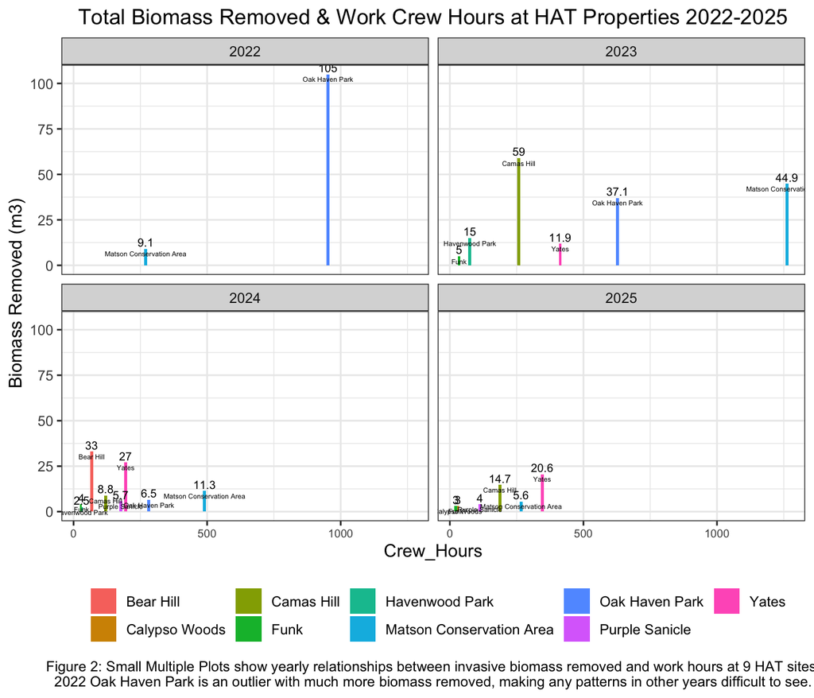